# A2: What effect does statistics anxiety have on attainment?

## 3.3 Exclusions

As in the Week 8 workshop, we require students to answer “Yes” to the final attention-amnesty question and to pass both attention checks in the anxiety block (`Q7.1_24 == 1` in STARS, `Q8.1_21 == 5` in STARS-M), since that block contains our predictor. Two Turkish universities never administered the embedded checks, so a check only counts against students at universities that used it. We test the four checks in later blocks of the survey in Section 3.6. All students with grades said they were undergraduates studying statistics. As a check, applied to all Sussex responses these rules keep 375 students, matching the 375 in the Week 8 workshop.

```r
pass_check <- function(x, correct, uni) (x %in% correct) | !ave(!is.na(x), uni, FUN = any)
checks <- smarvus_raw %>%
  transmute(unique_id,
            amnesty_ok = attention_amnesty %in% "Yes",
            anxiety_checks_ok = pass_check(Q7.1_24, 1, university) & pass_check(Q8.1_21, 5, university),
            later_checks_ok = pass_check(Q9.1_22, 1, university) & pass_check(Q11.1_9, 3, university) &
                              pass_check(Q13.1_17, 2, university) & pass_check(Q15.1_9, 4, university))
step1 <- has_grade %>% left_join(checks, by = "unique_id")
step2 <- step1 %>% filter(!is.na(grade_num))
step3 <- step2 %>% filter(amnesty_ok)
step4 <- step3 %>% filter(anxiety_checks_ok)
step5 <- step4 %>% filter(!is.na(stars_score))
```

```r
standardise_within_module <- function(dat, x = "stars_score", min_n = 10) {
  dat %>%
    filter(!is.na(grade_num), !is.na(.data[[x]])) %>%
    group_by(module) %>% filter(n() >= min_n) %>%
    mutate(grade_z = as.numeric(scale(grade_num)), stars_z = as.numeric(scale(.data[[x]]))) %>%
    ungroup() %>% filter(!is.na(grade_z), !is.na(stars_z))
}
analysis_data <- standardise_within_module(step5)
```

Table 2: Students remaining after each exclusion step.

| Official grade recorded | Grade converted to a number | ‘Yes’ to attention amnesty | Passed anxiety-block attention checks | Complete STARS | Module has 10+ students |
| --- | --- | --- | --- | --- | --- |
| 1824 | 1817 | 1695 | 1623 | 1617 | 1571 |

The final sample has **N = 1571** students in 28 modules at 18 universities in 12 countries, and 91% of them study psychology. Psychology students typically take statistics as a compulsory, non-specialist part of their degree, so the results may not carry over to students who chose a quantitative subject. STARS totals are roughly symmetric (mean 67.1, SD 18.8). Standardised grades have a long left tail from a few very low marks (fails or non-submissions), which we check in Section 3.6.

## 3.4 Main analysis: multilevel model

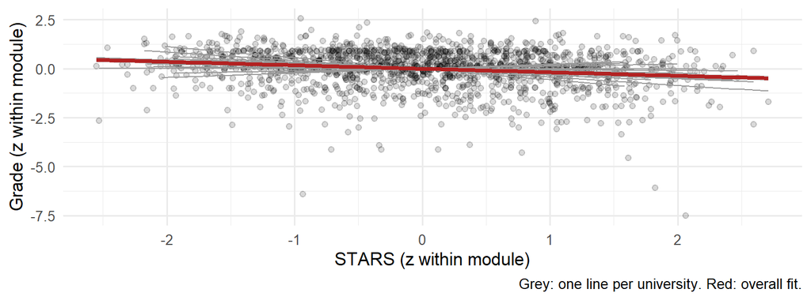

```r
ggplot(analysis_data, aes(stars_z, grade_z)) +
  geom_point(alpha = 0.15) +
  geom_smooth(aes(group = university), method = "lm", se = FALSE, colour = "grey60", linewidth = 0.4) +
  geom_smooth(method = "lm", colour = "firebrick", linewidth = 1.2) +
  labs(x = "STARS (z within module)", y = "Grade (z within module)",
       caption = "Grey: one line per university. Red: overall fit.")
```

Students are grouped within universities, and the relationship could differ between universities (e.g. because of different assessment types). We therefore fit a linear mixed model with a **random slope for university**: grade<sub>ij</sub> = (β + u<sub>j</sub>) × STARS<sub>ij</sub> + ε<sub>ij</sub>, with u<sub>j</sub> ~ N(0, σ<sub>u</sub><sup>2</sup>). Both variables have mean 0 within each module, so the model needs no intercept.

```r
main_model <- lmer(grade_z ~ 0 + stars_z + (0 + stars_z | university), data = analysis_data)
summary(main_model)$coefficients
```

```
##           Estimate Std. Error       df  t value    Pr(>|t|)
## stars_z -0.1765322 0.03210856 6.753652 -5.49798 0.001025094
```

```r
main_beta <- unname(fixef(main_model)["stars_z"])
main_ci <- unname(confint(main_model, parm = "stars_z", method = "profile"))
```

Both variables are standardised within module, so β is a pooled within-module correlation: r = -0.18, 95% CI [-0.24, -0.11]. The SD of the slope across universities is small (0.07). As in the Week 8 lecture, we convert r to d with `effectsize::r_to_d()` (d = 2r / √(1 − r<sup>2</sup>)), applying it to the estimate and to both ends of the confidence interval:

```r
main_d <- r_to_d(c(main_beta, main_ci))
n_main <- nrow(analysis_data)
main_d
```

```
## [1] -0.3586978 -0.4972596 -0.2182665
```

## 3.5 Other variables (Terry et al., 2023, Sections 2.4–2.5)

**Variables we considered:**

- **Possible confounders:** gender, age, year of study and specific learning differences (SpLDs, e.g. dyscalculia), as well as maths anxiety and trait anxiety, which overlap with statistics anxiety.
- **Prior maths attainment:** a likely confounder, but it is recorded in country-specific formats (GCSE, Abitur, etc.) that can’t be compared, so we don’t adjust for it.
- **Variables that affect generalisation:** degree subject and university. We handle university through standardisation and the random slopes, and degree subject in Section 3.6.

The adjusted models below answer a **different question** from the main analysis. The research question asks about the *overall* association. An adjusted model asks about the association that remains with other variables held fixed. So we report these as extra information, not as our headline d.

```r
covs <- analysis_data %>%
  mutate(gender = fct_lump_min(replace_na(gender, "Missing"), 30, other_level = "Other/missing"),
         across(c(age, degree_year), ~ replace_na(.x, "Missing")),
         spld = case_when(is.na(spld) ~ "Missing", spld == "I do not have an SpLD" ~ "No", TRUE ~ "Yes"))
m_demog <- lmer(grade_z ~ stars_z + gender + age + degree_year + spld + (0 + stars_z | university), data = covs)

anx <- analysis_data %>% filter(!is.na(rmars_score), !is.na(sticsa_score)) %>% group_by(module) %>%
  mutate(rmars_z = as.numeric(scale(rmars_score)), sticsa_z = as.numeric(scale(sticsa_score))) %>% ungroup()
m_anx <- lmer(grade_z ~ 0 + stars_z + rmars_z + sticsa_z + (0 + stars_z | university), data = anx)

coef_row <- function(m, term, label) {
  ci <- confint(m, parm = term, method = "Wald")
  tibble(Model = label, Term = term, N = nobs(m), Coef = round(fixef(m)[term], 3),
         `95% CI` = paste0("[", fmt(ci[1]), ", ", fmt(ci[2]), "]"))
}
bind_rows(coef_row(m_demog, "stars_z", "+ gender, age, year, SpLD"),
          map_dfr(c("stars_z", "rmars_z", "sticsa_z"), ~ coef_row(m_anx, .x, "+ maths and trait anxiety"))) %>%
  kable(caption = "Table 3: Standardised coefficients from the adjusted models.")
```

Table 3: Standardised coefficients from the adjusted models.

| Model | Term | N | Coef | 95% CI |
| --- | --- | --- | --- | --- |
| + gender, age, year, SpLD | stars_z | 1571 | -0.192 | [-0.25, -0.13] |
| + maths and trait anxiety | stars_z | 1564 | -0.144 | [-0.23, -0.06] |
| + maths and trait anxiety | rmars_z | 1564 | -0.030 | [-0.10, 0.05] |
| + maths and trait anxiety | sticsa_z | 1564 | -0.029 | [-0.09, 0.03] |

Adjusting for demographics barely changes the STARS coefficient. Maths anxiety correlates strongly with STARS (r = 0.76), yet adding it and trait anxiety reduces the STARS coefficient only a little, and neither shows a clear association of its own. So the link with grades in a *statistics* module appears to be specific to statistics anxiety.

## 3.6 Robustness: how much do our choices matter?

The many-analysts studies discussed in the Week 9 lecture (e.g. Silberzahn et al., 2018) show that reasonable choices can change results (the “garden of forking paths”; Gelman & Loken, 2013). We therefore re-ran the analysis under alternative choices:

```r
d_lmer <- function(dat) {
  m <- lmer(grade_z ~ 0 + stars_z + (0 + stars_z | university), data = dat)
  c(N = nrow(dat), r_to_d(c(fixef(m), confint(m, parm = "stars_z", method = "Wald"))))
}
ct <- cor.test(analysis_data$stars_z, analysis_data$grade_z)
mod_r <- analysis_data %>% group_by(module) %>% summarise(n = n(), r = cor(stars_z, grade_z))
ma <- rma(escalc("ZCOR", ri = mod_r$r, ni = mod_r$n))
ranks <- analysis_data %>% group_by(module) %>%
  mutate(grade_z = as.numeric(scale(rank(grade_num))), stars_z = as.numeric(scale(rank(stars_score)))) %>% ungroup()
sub <- function(dat, ...) d_lmer(standardise_within_module(dat, ...))

rob <- rbind(
  "Main analysis" = c(N = n_main, main_d),
  "(a) Pooled correlation, no random effects" = c(N = n_main, r_to_d(c(ct$estimate, ct$conf.int))),
  "(b) Meta-analysis of module correlations" = c(N = n_main, r_to_d(transf.ztor(c(ma$b, ma$ci.lb, ma$ci.ub)))),
  "(c) Ranks instead of z-scores" = d_lmer(ranks),
  "(d) Pass all six embedded attention checks" = sub(filter(step5, later_checks_ok)),
  "(e) Psychology/education/social science only" =
        sub(filter(step5, degree_major %in% c("Psychology", "Education", "Social Sciences"))),
  "(f) 1st and 2nd year students only" = sub(filter(step5, degree_year %in% c("1st Year", "2nd Year"))),
  "(g) Modules with 30+ students" = sub(step5, min_n = 30),
  "(h) R-MARS-S instead of STARS" = sub(filter(step4, !is.na(rmarss_score)), x = "rmarss_score"),
  "(i) STARS test-anxiety subscale" = sub(step5, x = "stars_test"),
  "(j) STARS interpretation subscale" = sub(step5, x = "stars_interp"),
  "(k) STARS asking-for-help subscale" = sub(step5, x = "stars_help"))
rob_tbl <- as_tibble(rob, rownames = "Analysis") %>%
  set_names(c("Analysis", "N", "d", "CI lower", "CI upper")) %>%
  mutate(N = as.integer(N), across(d:`CI upper`, ~ round(.x, 2)))
kable(rob_tbl, caption = "Table 4: Cohen's d under alternative analysis choices.")
```

Table 4: Cohen’s d under alternative analysis choices.

| Analysis | N | d | CI lower | CI upper |
| --- | --- | --- | --- | --- |
| Main analysis | 1571 | -0.36 | -0.50 | -0.22 |
| (a) Pooled correlation, no random effects | 1571 | -0.36 | -0.46 | -0.26 |
| (b) Meta-analysis of module correlations | 1571 | -0.37 | -0.49 | -0.25 |
| (c) Ranks instead of z-scores | 1571 | -0.35 | -0.50 | -0.21 |
| (d) Pass all six embedded attention checks | 1535 | -0.34 | -0.48 | -0.21 |
| (e) Psychology/education/social science only | 1537 | -0.35 | -0.49 | -0.22 |
| (f) 1st and 2nd year students only | 1437 | -0.36 | -0.48 | -0.24 |
| (g) Modules with 30+ students | 1390 | -0.36 | -0.47 | -0.24 |
| (h) R-MARS-S instead of STARS | 1571 | -0.35 | -0.48 | -0.22 |
| (i) STARS test-anxiety subscale | 1571 | -0.30 | -0.42 | -0.18 |
| (j) STARS interpretation subscale | 1571 | -0.36 | -0.49 | -0.23 |
| (k) STARS asking-for-help subscale | 1571 | -0.29 | -0.40 | -0.18 |

Every version gives d between -0.37 and -0.29, and none of the confidence intervals includes zero. There is little heterogeneity between modules (I<sup>2</sup> = 16%). Three findings are worth highlighting:

- The rank-based version (c) gives the same answer, so neither the very low marks nor the coding of letter grades drives the result.
- R-MARS-S (h) agrees with STARS.
- All three subscales give similar values, so no single aspect of statistics anxiety is responsible.

## 3.7 Interpretation and limitations

Students with more statistics anxiety tended to get lower grades on their statistics module than their classmates. The association is consistent across universities, models, exclusion rules and anxiety measures, but it is modest. With r = -0.18, one SD more anxiety goes with grades about 0.18 SD lower, and anxiety explains only about 3% of the variation in grades within a module. Expressed as d = -0.36, the effect falls between Cohen’s “small” (0.2) and “medium” (0.5) benchmarks.

- **Association, not effect.** The data are observational. Struggling students may *become* anxious (anxiety was measured during the module), and prior attainment may affect both anxiety and grades. Section 3.5 rules out demographics and general or maths anxiety as explanations, but not prior attainment. So d should not be read as what reducing anxiety would achieve.
- **Comparing d values.** Our d is a re-expression of a correlation, not a difference between two groups. It should not be compared directly with d values from intervention studies, such as the average of about 0.1 for education RCTs reported by Kraft (2020).
- **Generalisability.** The data come from 18 universities, mostly in the UK and Europe, and the students are mostly psychology students. Students who consented to grade linkage and passed the attention checks may differ from the rest. Standardising grades also ignores differences in *what* is assessed (e.g. exams vs coursework).

**Conclusion:** statistics anxiety has a reliable but modest negative association with attainment, d = -0.36 [-0.50, -0.22], N = 1571. These data cannot show whether it is causal.

## References

Gelman, A., & Loken, E. (2013). *The garden of forking paths: Why multiple comparisons can be a problem, even when there is no “fishing expedition” or “p-hacking” and the research hypothesis was posited ahead of time* [Unpublished manuscript]. Department of Statistics, Columbia University. http://www.stat.columbia.edu/~gelman/research/unpublished/p_hacking.pdf

Kraft, M. A. (2020). Interpreting effect sizes of education interventions. *Educational Researcher, 49*(4), 241–253. https://doi.org/10.3102/0013189X20912798

Silberzahn, R., Uhlmann, E. L., Martin, D. P., Anselmi, P., Aust, F., Awtrey, E., … Nosek, B. A. (2018). Many analysts, one data set: Making transparent how variations in analytic choices affect results. *Advances in Methods and Practices in Psychological Science, 1*(3), 337–356. https://doi.org/10.1177/2515245917747646

Terry, J., Ross, R. M., Nagy, T., Salgado, M., Garrido-Vásquez, P., Sarfo, J. O., … Field, A. P. (2023). Data from an international multi-centre study of statistics and mathematics anxieties and related variables in university students (the SMARVUS dataset). *Journal of Open Psychology Data, 11*(1), 8. https://doi.org/10.5334/jopd.80